# Project: Investigating Medical Appointments - [No-show appointments]

- Introduction
- Data Wrangling
- Exploratory Data Analysis
- Conclusions

## Introduction

### Dataset Description

No_show is a situation in which a patient did not show up for an appointment initially scheduled with the doctor. This means that valuable time could be lost waiting for the patient to show up. Therefore, it will be helpful to have some insight into the reason why this happen and to be able to reduce their occurence.

The data set that was used for this analysis was obtained from kaggle site and was downloaded from [here](https://www.kaggle.com/joniarroba/noshowappointments). This dataset contain information about over 100,000 medical appointments in different hospitals across Brazil.

The data set contains the following columns:

**1** `The patientID`: This is a unique identifier for each of the patients this column will be dropped during the analysis because we desire to find general patterns within the population

**3** `Gender`: The patient in our data set were identified as either male or female. This will be an indicator to consider if male or female tend to keep their appointments

**4** `ScheduledDay` and the `AppointmentDay`: This describe the day the patient schedule the meeting and the day the appointment was scheduled. we will engineer several other features from this two column that will enable us determine the waiting time and the weekday as we try to uncover various indicators for noshow appointment.

**5** `Age`: Age has always been identified as a factor associated with predisposition to certain types of disease and it will be a factor to consider with respect to whether an individual will show up or not. also we will love to know which age group have a higher ratio of showing up for appointment

**6** `Neighborhood`: This shows the location of the hospital. We will be able to consider the prevalence of noshow appointment by locality.

**7** `Scholarship`: This column name will be changed to 'sponsorship' to better reflect the implication as it describes those patient enrolled into Brasilian social welfare program Bolsa Familia. those enrolled are recoreded as 1 while those not enrolled are recorded as o

**8** `Hipertension`, `Diabetes`, `Alcoholism`: These are particular ailments of patients collected in the dataset. we will be analysing to uncover patterns on tendency to show up or not for their appointments. patient with this ailment are recorded with a 1 and those without the ailment are recorded with a 0 for their respective column.

**9** `Handcap` There are five unique variable in this column describing whether a patient has any physical disability and the types are tagged 1,2,3,or 4. If a person does not have a diability it is recorded as 0.

**10** `SMS_recieved`:Getting a reminder can sometimes be helpful in ensuring that the scheduled appointment was honored. it will be interesting to see how effective is this strategy in improving the numbers of appointment kept.

**11** `No_show`: This is our target variable and we will be answering many question from the analysis, to discover patterns across the other feature variables that influence the outcome of this variable. The column has been coded as **Yes** or **No** `Yes`: indicating that a patient did not show up and `No`: indicating that a patient showed up for the appointment.

For clearity, we will substitute this column with a more descriptive column, `status` which will have two values, `show` and `no_show`. `show` indicates that the patient showed up `no_show` indicates that the patient did not show up.

### Question(s) for Analysis

> the focus of this analysis is to answer the question. `What are the features that best describes patient that showed up for their appointment amongst the features available in the dataset`? we will consider this question from different perspectives like, the Age and Gender of the patient, the time factors like the waiting time and the day of the week of the appointment, the type of ailment, the handicap status and the type of disability, the enrolment status in the national welfare program, the status of SMS_recieved as well as the locality of the hospital.

```python
# importing required packages
import pandas as pd
import numpy as np
import datetime as dt
import matplotlib.pyplot as plt

%matplotlib inline
```

```python
#loading in the data
df=pd.read_csv("noshowappointments.csv")
```

## Data Wrangling

> In this section the data will be cleaned, inconsistencies will be discovered and dealt with appropriately and our data set will be prepared for exploration. The Data wrangling was done in the following steps

First a quick glance through the data

Converting to Datetime object

cross_validation

Feature Engineering of Datetime object

Create and Rename some column

Dropping some column

#### A quick glance through the data

We can see that their are 110,527 observations and 14 features

There are nine numerical fields and 5 text type field

There are no duplicate observations

The average age of the population is 37 years old, minimum age is -1 and maximum age is 115 years.

The 9.8% of the patients are enrolled into the Bolsa Familia welfare program.

```python
# viewing the first 5 rows
df.head()
```

|  | PatientId | AppointmentID | Gender | ScheduledDay | AppointmentDay | Age | Neighbourhood | Scholarship | Hipertension | Diabetes | Alcoholism | Handcap | SMS_received | No-show |
| --- | --- | --- | --- | --- | --- | --- | --- | --- | --- | --- | --- | --- | --- | --- |
| 0 | 2.987250e+13 | 5642903 | F | 2016-04-29T18:38:08Z | 2016-04-29T00:00:00Z | 62 | JARDIM DA PENHA | 0 | 1 | 0 | 0 | 0 | 0 | No |
| 1 | 5.589978e+14 | 5642503 | M | 2016-04-29T16:08:27Z | 2016-04-29T00:00:00Z | 56 | JARDIM DA PENHA | 0 | 0 | 0 | 0 | 0 | 0 | No |
| 2 | 4.262962e+12 | 5642549 | F | 2016-04-29T16:19:04Z | 2016-04-29T00:00:00Z | 62 | MATA DA PRAIA | 0 | 0 | 0 | 0 | 0 | 0 | No |
| 3 | 8.679512e+11 | 5642828 | F | 2016-04-29T17:29:31Z | 2016-04-29T00:00:00Z | 8 | PONTAL DE CAMBURI | 0 | 0 | 0 | 0 | 0 | 0 | No |
| 4 | 8.841186e+12 | 5642494 | F | 2016-04-29T16:07:23Z | 2016-04-29T00:00:00Z | 56 | JARDIM DA PENHA | 0 | 1 | 1 | 0 | 0 | 0 | No |

```python
# The shape of the data
df.shape
```

```
(110527, 14)
```

```python
# The general patterns across numerical fields
df.describe()
```

|  | PatientId | AppointmentID | Age | Scholarship | Hipertension | Diabetes | Alcoholism | Handcap | SMS_received |
| --- | --- | --- | --- | --- | --- | --- | --- | --- | --- |
| count | 1.105270e+05 | 1.105270e+05 | 110527.000000 | 110527.000000 | 110527.000000 | 110527.000000 | 110527.000000 | 110527.000000 | 110527.000000 |
| mean | 1.474963e+14 | 5.675305e+06 | 37.088874 | 0.098266 | 0.197246 | 0.071865 | 0.030400 | 0.022248 | 0.321026 |
| std | 2.560949e+14 | 7.129575e+04 | 23.110205 | 0.297675 | 0.397921 | 0.258265 | 0.171686 | 0.161543 | 0.466873 |
| min | 3.921784e+04 | 5.030230e+06 | -1.000000 | 0.000000 | 0.000000 | 0.000000 | 0.000000 | 0.000000 | 0.000000 |
| 25% | 4.172614e+12 | 5.640286e+06 | 18.000000 | 0.000000 | 0.000000 | 0.000000 | 0.000000 | 0.000000 | 0.000000 |
| 50% | 3.173184e+13 | 5.680573e+06 | 37.000000 | 0.000000 | 0.000000 | 0.000000 | 0.000000 | 0.000000 | 0.000000 |
| 75% | 9.439172e+13 | 5.725524e+06 | 55.000000 | 0.000000 | 0.000000 | 0.000000 | 0.000000 | 0.000000 | 1.000000 |
| max | 9.999816e+14 | 5.790484e+06 | 115.000000 | 1.000000 | 1.000000 | 1.000000 | 1.000000 | 4.000000 | 1.000000 |

Here we can see a basic summary about the numerical fields in the data set. some interesting info are:

The average age is 37 years, the minimum age is -1 while the oldest patient on the record is 115 years old.

9.8% of the population are enrolled in the Bolsa Familia welfare program.

19.7% of the population has Hypertension.

7% suffers from Diabetes.

3% were scheduled to see the doctor for Alcoholism.

```python
df.info()
```

```
<class 'pandas.core.frame.DataFrame'>
RangeIndex: 110527 entries, 0 to 110526
Data columns (total 14 columns):
 #   Column          Non-Null Count   Dtype
---  ------          --------------   -----
 0   PatientId       110527 non-null  float64
 1   AppointmentID   110527 non-null  int64
 2   Gender          110527 non-null  object
 3   ScheduledDay    110527 non-null  object
 4   AppointmentDay  110527 non-null  object
 5   Age             110527 non-null  int64
 6   Neighbourhood   110527 non-null  object
 7   Scholarship     110527 non-null  int64
 8   Hipertension    110527 non-null  int64
 9   Diabetes        110527 non-null  int64
 10  Alcoholism      110527 non-null  int64
 11  Handcap         110527 non-null  int64
 12  SMS_received    110527 non-null  int64
 13  No-show         110527 non-null  object
dtypes: float64(1), int64(8), object(5)
memory usage: 11.8+ MB
```

Here, we can see the that there are no null values as all the fields has the same number of non null values i.e. 110527. We can also see the data type for each column as well.

All the column seem to be in the approriate data type. However, we will change the ScheduledDay and AppointmetDay to Datetime object

It is also worth nothing that the Patientid and and AppointmentID should be a string but their data type will not be changed since the two columns will be dropped

```python
df.duplicated().sum()
```

```
0
```

A quick check for duplicated rows returned 0. confirming that there are no duplicated row

# The population distribution

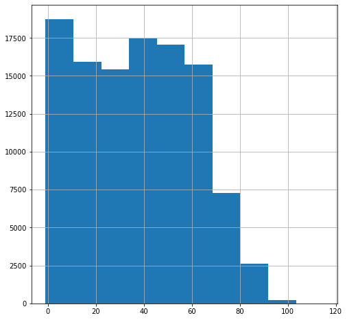

```python
df.Age.hist(figsize=(8,8));
```

##### The histogram shows that if the populations were grouped in tens then the largest group in the population will be those between the ages 0 and 10 followed by the age group between the age 40 and 50

# The minimum age was observed to be-1

This is not likely to be true. It must have been an error so we will drop that observation

```python
#dropped row with age -1

df=df.drop(df[df['Age']==-1].index)

#check
sum(df.Age==-1)
```

```
0
```

we can see that the row with age value -1 has been dropped

##### Apart from "Handcap" column with five different possibilities the rest fields have two unique possiblities.

```python
print("Unique values in column Handcap is {}".format(df["Handcap"].unique()))
print("Unique values in column Hipertension is {}".format(df["Hipertension"].unique()))
print("Unique values in column Diabetes is {}".format(df["Diabetes"].unique()))
print("Unique values in column Scholarship is {}".format(df["Scholarship"].unique()))
print("Unique values in column No-show is {}".format(df["No-show"].unique()))
print("Unique values in column Alcoholism is {}".format(df["Alcoholism"].unique()))
print("Unique values in column SMS_received is {}".format(df["SMS_received"].unique()))
print("Unique values in column Gender is {}".format(df["Gender"].unique()))
```

```
Unique values in column Handcap is [0 1 2 3 4]
Unique values in column Hipertension is [1 0]
Unique values in column Diabetes is [0 1]
Unique values in column Scholarship is [0 1]
Unique values in column No-show is ['No' 'Yes']
Unique values in column Alcoholism is [0 1]
Unique values in column SMS_received is [0 1]
Unique values in column Gender is ['F' 'M']
```

##### There are 81 unique Neighbourhoods

```python
print("Unique values in column Neighbourhood are {}".format(df["Neighbourhood"].unique()))
print("The total number of unique Neighbourhood is {}".format(len(df["Neighbourhood"].unique())))
```

```
Unique values in column Neighbourhood are ['JARDIM DA PENHA' 'MATA DA PRAIA' 'PONTAL DE CAMBURI' 'REPÚBLICA'
 'GOIABEIRAS' 'ANDORINHAS' 'CONQUISTA' 'NOVA PALESTINA' 'DA PENHA'
 'TABUAZEIRO' 'BENTO FERREIRA' 'SÃO PEDRO' 'SANTA MARTHA' 'SÃO CRISTÓVÃO'
 'MARUÍPE' 'GRANDE VITÓRIA' 'SÃO BENEDITO' 'ILHA DAS CAIEIRAS'
 'SANTO ANDRÉ' 'SOLON BORGES' 'BONFIM' 'JARDIM CAMBURI' 'MARIA ORTIZ'
 'JABOUR' 'ANTÔNIO HONÓRIO' 'RESISTÊNCIA' 'ILHA DE SANTA MARIA'
 'JUCUTUQUARA' 'MONTE BELO' 'MÁRIO CYPRESTE' 'SANTO ANTÔNIO' 'BELA VISTA'
 'PRAIA DO SUÁ' 'SANTA HELENA' 'ITARARÉ' 'INHANGUETÁ' 'UNIVERSITÁRIO'
 'SÃO JOSÉ' 'REDENÇÃO' 'SANTA CLARA' 'CENTRO' 'PARQUE MOSCOSO'
 'DO MOSCOSO' 'SANTOS DUMONT' 'CARATOÍRA' 'ARIOVALDO FAVALESSA'
 'ILHA DO FRADE' 'GURIGICA' 'JOANA D´ARC' 'CONSOLAÇÃO' 'PRAIA DO CANTO'
 'BOA VISTA' 'MORADA DE CAMBURI' 'SANTA LUÍZA' 'SANTA LÚCIA'
 'BARRO VERMELHO' 'ESTRELINHA' 'FORTE SÃO JOÃO' 'FONTE GRANDE'
 'ENSEADA DO SUÁ' 'SANTOS REIS' 'PIEDADE' 'JESUS DE NAZARETH'
 'SANTA TEREZA' 'CRUZAMENTO' 'ILHA DO PRÍNCIPE' 'ROMÃO' 'COMDUSA'
 'SANTA CECÍLIA' 'VILA RUBIM' 'DE LOURDES' 'DO QUADRO' 'DO CABRAL' 'HORTO'
 'SEGURANÇA DO LAR' 'ILHA DO BOI' 'FRADINHOS' 'NAZARETH' 'AEROPORTO'
 'ILHAS OCEÂNICAS DE TRINDADE' 'PARQUE INDUSTRIAL']
The total number of unique Neighbourhood is 81
```

##### There are 103 unique ages in the data set

```python
print("Unique values in column Age are {}".format(df["Age"].unique()))
print("Unique values in column Age is {}".format(len(df["Age"].unique())))
```

```
Unique values in column Age are [ 62  56   8  76  23  39  21  19  30  29  22  28  54  15  50  40  46   4
  13  65  45  51  32  12  61  38  79  18  63  64  85  59  55  71  49  78
  31  58  27   6   2  11   7   0   3   1  69  68  60  67  36  10  35  20
  26  34  33  16  42   5  47  17  41  44  37  24  66  77  81  70  53  75
  73  52  74  43  89  57  14   9  48  83  72  25  80  87  88  84  82  90
  94  86  91  98  92  96  93  95  97 102 115 100  99]
Unique values in column Age is 103
```

`return`

wrangling

### converting to Datetime object

Parse Scheduledday and AppointmentDay as datetime Convert the date Scheduled- date and the Appointment date to a datetime object. here we will only work with the date value of the date time object. especially because the time value is not available on the appointmentday field.

The data collection overall span between **November** 2015 and June 2016. That is just about `8 months`.

```python
#converting ScheduleDay to datetime
df["ScheduledDay"]=pd.to_datetime(df["ScheduledDay"],format="%Y-%m-%d %H:%M:%S")
df["ScheduledDay"]=df["ScheduledDay"].dt.date
```

```python
#converting AppointmentDay to datetime
df["AppointmentDay"]=pd.to_datetime(df["AppointmentDay"],format="%Y-%m-%d %H:%M:%S")
df["AppointmentDay"]=df["AppointmentDay"].dt.date
```

```python
df["ScheduledDay"].min()
```

```
datetime.date(2015, 11, 10)
```

```python
df["AppointmentDay"].min()
```

```
datetime.date(2016, 4, 29)
```

```python
df["ScheduledDay"].max()
```

```
datetime.date(2016, 6, 8)
```

```python
df["ScheduledDay"].max()
```

```
datetime.date(2016, 6, 8)
```

`return`

wrangling

### Cross validation

performing a cross validation on the scheduleday and appointmentday to ensure that they make sense

It was observed that there are 5 observations where the waiting time is less than zero. This is not consistent with logic since the appointment should have at least been scheduled at a previous day or on the same day

```python
# finding the waiting time

df["Waiting_time"]= df["AppointmentDay"] - df["ScheduledDay"]

#convert waiting time to value in days
df['Waiting_time']=df['Waiting_time'].dt.days

df[df["Waiting_time"]<0]
```

|  | PatientId | AppointmentID | Gender | ScheduledDay | AppointmentDay | Age | Neighbourhood | Scholarship | Hipertension | Diabetes | Alcoholism | Handcap | SMS_received | No-show | Waiting_time |
| --- | --- | --- | --- | --- | --- | --- | --- | --- | --- | --- | --- | --- | --- | --- | --- |
| 27033 | 7.839273e+12 | 5679978 | M | 2016-05-10 | 2016-05-09 | 38 | RESISTÊNCIA | 0 | 0 | 0 | 0 | 1 | 0 | Yes | -1 |
| 55226 | 7.896294e+12 | 5715660 | F | 2016-05-18 | 2016-05-17 | 19 | SANTO ANTÔNIO | 0 | 0 | 0 | 0 | 1 | 0 | Yes | -1 |
| 64175 | 2.425226e+13 | 5664962 | F | 2016-05-05 | 2016-05-04 | 22 | CONSOLAÇÃO | 0 | 0 | 0 | 0 | 0 | 0 | Yes | -1 |
| 71533 | 9.982316e+14 | 5686628 | F | 2016-05-11 | 2016-05-05 | 81 | SANTO ANTÔNIO | 0 | 0 | 0 | 0 | 0 | 0 | Yes | -6 |
| 72362 | 3.787482e+12 | 5655637 | M | 2016-05-04 | 2016-05-03 | 7 | TABUAZEIRO | 0 | 0 | 0 | 0 | 0 | 0 | Yes | -1 |

These are the 5 rows with negative waiting time

### dropping those observation with negative waiting time

```python
#dropping rows with negative waiting time
df.drop(df[df["Waiting_time"]<0].index,inplace = True)
#confirming that they are dropped
df[df["Waiting_time"] < 0]
```

|  | PatientId | AppointmentID | Gender | ScheduledDay | AppointmentDay | Age | Neighbourhood | Scholarship | Hipertension | Diabetes | Alcoholism | Handcap | SMS_received | No-show | Waiting_time |
| --- | --- | --- | --- | --- | --- | --- | --- | --- | --- | --- | --- | --- | --- | --- | --- |

All rows with negative waiting time succesfully dropped

### Feature engineering of Datetime objects

feature engineering from the AppointmentDay and ScheduledDay

Here the day of the week will be extracted from the appointmentDay field to help answer questions like, which day are people more likely to show up for their appointment? Do people show up more or less on weekends?

### All the appointment year was in 2016 and the scheduled year was from 2015 to 2016

```python
df["schedule_year"]=pd.to_datetime(df["ScheduledDay"]).dt.year
df["schedule_year"].unique()
```

```
array([2016, 2015], dtype=int64)
```

The schedule year range between 2015 and 2016

```python
df["appointment_year"]=pd.to_datetime(df["AppointmentDay"]).dt.year
df["appointment_year"].unique()
```

```
array([2016], dtype=int64)
```

The appointment year was only 2016 since the data was collected within a 1 year periodwe will not be taking this year value into consideration during our analysis

### Extract the appointment_weekday column from the AppointmentDay column

```python
df["appointment_weekday"]=pd.to_datetime(df["AppointmentDay"]).dt.weekday
df["appointment_weekday"].unique()
```

```
array([4, 1, 0, 2, 3, 5], dtype=int64)
```

now we have the weekday value, with 0 as Monday, 1 as Tuesday, 2 as Wednesday, 3 as Thursday,4 as Friday and 5 as Saturday

`return`

wrangling

### Create and Rename some column

###### For clearity create a new column **status** that will properly represent the status of the appointment **show** for **No** and **no-show** for **yes**

###### Also, we will change the column name `Scholarship` to `sponsorship`

```python
# first select the status with "No" values and count the numbers
df_status_No=df["No-show"]=="No"
sum(df_status_No)
```

```
88207
```

```python
#create an array of 88208 "show"
shows=np.repeat("show",88207)
```

```python
# "show" status for every "No" in "No-show"
df.loc[df_status_No,'status']=shows
```

It can be observed that there are **22314** status with **Yes** value..i.e 22314 times people did not show up for their appointment

```python
# we will follow the same step for the yes status representing it as no-show
df_status_yes=df["No-show"]=="Yes"
sum(df_status_yes)
```

```
22314
```

```python
no_shows=np.repeat("no-show",22314)
```

```python
# "no-show" status for every "Yes" in "No-show"
df.loc[df_status_yes,'status']=no_shows
```

```python
# renaming scholarship to sponsorship
df=df.rename(columns={'Scholarship':'sponsorship'})
df.head()
```

|  | PatientId | AppointmentID | Gender | ScheduledDay | AppointmentDay | Age | Neighbourhood | sponsorship | Hipertension | Diabetes | Alcoholism | Handcap | SMS_received | No-show | Waiting_time | schedule_year | appointment_year | appointment_weekday | status |
| --- | --- | --- | --- | --- | --- | --- | --- | --- | --- | --- | --- | --- | --- | --- | --- | --- | --- | --- | --- |
| 0 | 2.987250e+13 | 5642903 | F | 2016-04-29 | 2016-04-29 | 62 | JARDIM DA PENHA | 0 | 1 | 0 | 0 | 0 | 0 | No | 0 | 2016 | 2016 | 4 | show |
| 1 | 5.589978e+14 | 5642503 | M | 2016-04-29 | 2016-04-29 | 56 | JARDIM DA PENHA | 0 | 0 | 0 | 0 | 0 | 0 | No | 0 | 2016 | 2016 | 4 | show |
| 2 | 4.262962e+12 | 5642549 | F | 2016-04-29 | 2016-04-29 | 62 | MATA DA PRAIA | 0 | 0 | 0 | 0 | 0 | 0 | No | 0 | 2016 | 2016 | 4 | show |
| 3 | 8.679512e+11 | 5642828 | F | 2016-04-29 | 2016-04-29 | 8 | PONTAL DE CAMBURI | 0 | 0 | 0 | 0 | 0 | 0 | No | 0 | 2016 | 2016 | 4 | show |
| 4 | 8.841186e+12 | 5642494 | F | 2016-04-29 | 2016-04-29 | 56 | JARDIM DA PENHA | 0 | 1 | 1 | 0 | 0 | 0 | No | 0 | 2016 | 2016 | 4 | show |

column name 'Scholarship' successfully changed to 'Sponsorship'

`return`

wrangling

### Droping some columns

##### Finally, we will drop the following columns scheduledDay, AppointmentDay, PatientId AppointmentID and No-show, schedule_year and appointment_year

`PatientId`**:** we will drop patientId because our interest is in finding general patterns across the population

`AppointmentID`**:** We will drop appointmentID because It has no significant value to the investigation.

`ScheduledDay and AppointmentDay`**:** we have already engineered important features out of the scheduledDay and AppointmentDay therefore we have no more need of these fields.

`No-show`**:** we have already created a more descriptive column of the appointment status in the `status` field, so we have no need of the `No-show` field

`schedule_year` and `appointment_year`**:** The appointment year and schedule_year is of little analytical value since the data collection spaned between `2015` and `2016` and lasted only for `8 months`

```python
df_cleaned=df.drop(["PatientId","AppointmentID","ScheduledDay", "AppointmentDay","No-show","schedule_year","appointment_year"],axis=1)
df_cleaned.head()
```

|  | Gender | Age | Neighbourhood | sponsorship | Hipertension | Diabetes | Alcoholism | Handcap | SMS_received | Waiting_time | appointment_weekday | status |
| --- | --- | --- | --- | --- | --- | --- | --- | --- | --- | --- | --- | --- |
| 0 | F | 62 | JARDIM DA PENHA | 0 | 1 | 0 | 0 | 0 | 0 | 0 | 4 | show |
| 1 | M | 56 | JARDIM DA PENHA | 0 | 0 | 0 | 0 | 0 | 0 | 0 | 4 | show |
| 2 | F | 62 | MATA DA PRAIA | 0 | 0 | 0 | 0 | 0 | 0 | 0 | 4 | show |
| 3 | F | 8 | PONTAL DE CAMBURI | 0 | 0 | 0 | 0 | 0 | 0 | 0 | 4 | show |
| 4 | F | 56 | JARDIM DA PENHA | 0 | 1 | 1 | 0 | 0 | 0 | 0 | 4 | show |

All the above listed column successfully dropped. Now we have our cleaned data. Ready for Exploration.

## Exploratory Data Analysis

In this section, the cleaned Data set will be explored with the aim of answering this question. What are the features that best describes patient that showed up for their appointment amongst the features available in the dataset .

To help us answer this question,we will consider the following factors:

Which of the Genders Keep their appointment the more ?

Is age a strong indicator for whether an individual show up or not ?

Considering both age and gender, how does these relate with the appointment status?

Is waiting time an indicator for whether an individual show up or not?

Is the appointment week-day an indicator for whether an individual show up or not ?

Is there any relationship between the type of ailment and the appointment status ?

Is there any relationship between the Handicap type and the appointment status ?

Is there any relationship between the sponsorship status and the appointment status ?

How does scholarship and Handicap status affect the appointment status ?

Is there any relationship between the sms reminder and the appointment status?

`return`

introduction

### Research Question 1 (Which of the Genders Keep their appointment the more?)

```python
# what is the count of males that showed up as compared to those that did not show up
df_cleaned.groupby('Gender')['status'].value_counts()
```

```
Gender  status
F       show       57245
        no-show    14591
M       show       30962
        no-show     7723
Name: status, dtype: int64
```

From the value count of the status field we can see that `57245` female showed up as compared to `30962` male. That means more female showed up over all. Although it is also obvious that there are more females in the population than male.

### Now we will create a barchart to visualize the pattern

```python
# select all the female observations by their status
females=df[df["Gender"]=='F']


# count the observation
count_f=females['status'].value_counts()
count_f
```

```
show       57245
no-show    14591
Name: status, dtype: int64
```

the count of females status shows that there are `57245` times a female showed up for their appointment as against `14591` times when they did not show up

```python
#select all the male observation by their status
males=df[df["Gender"]=='M']


# count the observation
count_m=males['status'].value_counts()
count_m
```

```
show       30962
no-show     7723
Name: status, dtype: int64
```

The status count shows that there are 30962 times a male showed up for an an appointment while there are 7723 times they did not show up

```python
# create a list out of the counts
count_male=[count_m['show'],count_m['no-show']]
count_female=[count_f['show'],count_f['no-show']]
index=['show','no_show']
# create a data frame
df_gender=pd.DataFrame({'Male':count_male,'Female':count_female},index=index)
df_gender
```

|  | Male | Female |
| --- | --- | --- |
| show | 30962 | 57245 |
| no_show | 7723 | 14591 |

Here we have a dataframe showing the show and no_show count for male and female respectively

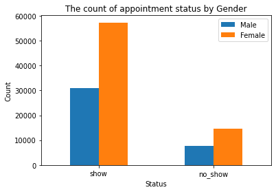

```python
# Plotting our result
_=df_gender.plot.bar()
plt.xlabel('Status')
plt.ylabel('Count')
plt.tick_params(axis='x',rotation=0)
plt.title('The count of appointment status by Gender');
```

### We observe a bias in the value of females that showed up because there were more female in the population being observed. It is better to compare the gender - status relationship by proportion

```python
# comparing by proportion
df_cleaned.groupby('Gender')['status'].value_counts(normalize=True)
```

```
Gender  status
F       show       0.796885
        no-show    0.203115
M       show       0.800362
        no-show    0.199638
Name: status, dtype: float64
```

Due to the larger population of females than male a fair comparison is to check the show and no-show rate for both gender We see that the female had 79.7% show rate while the Male had 80% show rate.

```python
#get proportion by gender
mean_gender_status=df_cleaned.groupby('Gender')['status'].value_counts(normalize=True)

female_prop=mean_gender_status['F']
male_prop=mean_gender_status['M']
```

### Plot proportion on a bar chart

```python
#setting the x locations
ind=np.arange(len(female_prop))
width=0.2
```

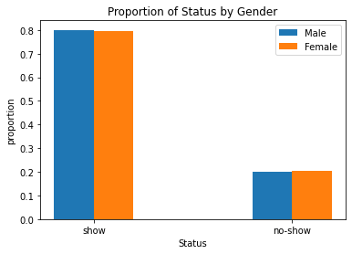

```python
# plot bars
male_bar=plt.bar(ind,male_prop,width,color='#1f77b4',label='Male')
female_bar=plt.bar(ind+width,female_prop,width,color='#ff7f0e',label='Female')

# title and labels
plt.ylabel('proportion')
plt.xlabel('Status')
plt.title('Proportion of Status by Gender')
locations=ind+width/2
labels=['show','no-show']
plt.xticks(locations,labels)

# legend
plt.legend();
```

### Proportion of status by Gender

Now we can see that `79.7`% of the females showed up for their appointment as compared to `80`% of males

eda

### Research Question 2 (Is age a strong indicator for whether an individual show up or not)

in order to simplify this analysis we are going to bin the ages into groups based on the similarities they share in susceptibility to diseases..

taking some guidance from research work by [Nophar G. et al](https://www.ncbi.nlm.nih.gov/pmc/articles/PMC3825015/) on "Redifining meaningful age group in the context of diseases", we will bin the ages into 10 groups as follows. `0-2`,`3-5`,`6-13`,`14-18`,`19-33`,`34-48`,`49-64`,`65-78`,`79-98`

```python
#creating the arguments
labels=["0-2","3-5","6-13","14-18","19-33","34-48","49-64","65-78","79-98","99-115"]

bins=[-1,2,5,13,18,33,48,64,78,99,115]

age=df_cleaned["Age"]
```

```python
# binning the ages into age groups
df_cleaned["Age_group"]=pd.cut(age,bins,labels)

#checking to ensure all ages were captured
df_cleaned[df_cleaned["Age_group"].isnull()]
```

|  | Gender | Age | Neighbourhood | sponsorship | Hipertension | Diabetes | Alcoholism | Handcap | SMS_received | Waiting_time | appointment_weekday | status | Age_group |
| --- | --- | --- | --- | --- | --- | --- | --- | --- | --- | --- | --- | --- | --- |

```python
# grouping the appointment status by age_group
age_group_status = df_cleaned.groupby('Age_group')['status'].value_counts()
age_group_status
```

```
Age_group  status
(-1, 2]    show        6124
           no-show     1306
(2, 5]     show        3422
           no-show      879
(5, 13]    show        7983
           no-show     2424
(13, 18]   show        4990
           no-show     1737
(18, 33]   show       16091
           no-show     5140
(33, 48]   show       17225
           no-show     4513
(48, 64]   show       20203
           no-show     4083
(64, 78]   show        9027
           no-show     1622
(78, 99]   show        3134
           no-show      607
(99, 115]  show           8
           no-show        3
Name: status, dtype: int64
```

here we can see the count of show and no-show for each age group observe that the largest show count is for age group 48-64 with a count of 20,203

```python
def unpacker (list_1,list_2,list_3):
    """
    unpacks a list into two lists based on their position in the list
    The first list contains all elements with even index
    The second list contains all elements with odd index.

    Args:
    arg_1(list): The list to be unpacked
    arg_2(list): The empty list to unpack all elements with even index
    arg_3(list): The empty list to unpack all elements with odd index


    Returns:
    list_1
    list_2
    """
    for a,x in enumerate(list_1):
      if a % 2 == 0:
       list_2.append(x)
      else:
       list_3.append(x)
    return list_2, list_3
```

Here is the defination of the unpacker function

```python
# unpack the age_group_status into two list 'show' and 'no_show'
show=[]
no_show=[]
unpacker(age_group_status,show,no_show)
print("show: {}".format(show))
print("no_show: {}".format(no_show))
```

```
show: [6124, 3422, 7983, 4990, 16091, 17225, 20203, 9027, 3134, 8]
no_show: [1306, 879, 2424, 1737, 5140, 4513, 4083, 1622, 607, 3]
```

Using the unpacker function, the age_group_status information was unpacked into two list show and no_show

```python
# create a dataframe out of these lists,index labels
df_age=pd.DataFrame({'Show':show,'No-show':no_show},index=labels)
df_age
```

|  | Show | No-show |
| --- | --- | --- |
| 0-2 | 6124 | 1306 |
| 3-5 | 3422 | 879 |
| 6-13 | 7983 | 2424 |
| 14-18 | 4990 | 1737 |
| 19-33 | 16091 | 5140 |
| 34-48 | 17225 | 4513 |
| 49-64 | 20203 | 4083 |
| 65-78 | 9027 | 1622 |
| 79-98 | 3134 | 607 |
| 99-115 | 8 | 3 |

This dataframe was created from the two list show and no_show and indexed by the age group list 7we can observe that three age group represent the group with the largest count age group `19-33` with 16091 show count, `34-48` with 17225 show count, `49-64` with 20203 show count.

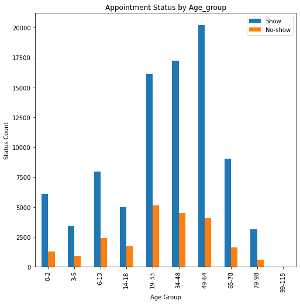

```python
df_age.plot(kind='bar', figsize=(8,8));
plt.title('Appointment Status by Age_group');
plt.xlabel('Age Group');
plt.ylabel('Status Count');
```

#### Appointment status by Age group

> This plot shows that the people that showed up the most for their appointment were between the age bracket of 49-64 years old with a value count of `20,203` followed by the age group 34-48 with a value count of `17,225` it can also be observed that those people within the group 19-33 has the highest no-show count of `5140`

> we can better compare the rate of no-show among these age groups by checking the proportion of no-show among the groups

```python
# grouping the appointment status by age_group and finding the percentage
norm_age_group_status = df_cleaned.groupby('Age_group')['status'].value_counts(normalize=True)
norm_age_group_status
```

```
Age_group  status
(-1, 2]    show       0.824226
           no-show    0.175774
(2, 5]     show       0.795629
           no-show    0.204371
(5, 13]    show       0.767080
           no-show    0.232920
(13, 18]   show       0.741787
           no-show    0.258213
(18, 33]   show       0.757901
           no-show    0.242099
(33, 48]   show       0.792391
           no-show    0.207609
(48, 64]   show       0.831878
           no-show    0.168122
(64, 78]   show       0.847685
           no-show    0.152315
(78, 99]   show       0.837744
           no-show    0.162256
(99, 115]  show       0.727273
           no-show    0.272727
Name: status, dtype: float64
```

norm_age_group_status contains the list of show and no_show rate for each of the age groups

```python
# unpack the age_group_status into to list 'show' and 'no_show'
show=[]
no_show=[]
unpacker(norm_age_group_status,show,no_show)
print("show: {}".format(show))
print("no_show: {}".format(no_show))
```

```
show: [0.8242261103633917, 0.7956289235061613, 0.7670798501008936, 0.7417868291957782, 0.7579011822335264, 0.7923912043426258, 0.8318784484888413, 0.8476852286599681, 0.8377439187383052, 0.7272727272727273]
no_show: [0.17577388963660834, 0.20437107649383865, 0.23292014989910637, 0.2582131708042218, 0.24209881776647355, 0.2076087956573742, 0.16812155151115868, 0.15231477134003193, 0.16225608126169475, 0.2727272727272727]
```

now there is a separate list for the show and no_show status in order of their age group

```python
# create a dataframe out of these lists,index labels
df_age_norm=pd.DataFrame({'Show':show,'No-show':no_show},index=labels)
df_age_norm
```

|  | Show | No-show |
| --- | --- | --- |
| 0-2 | 0.824226 | 0.175774 |
| 3-5 | 0.795629 | 0.204371 |
| 6-13 | 0.767080 | 0.232920 |
| 14-18 | 0.741787 | 0.258213 |
| 19-33 | 0.757901 | 0.242099 |
| 34-48 | 0.792391 | 0.207609 |
| 49-64 | 0.831878 | 0.168122 |
| 65-78 | 0.847685 | 0.152315 |
| 79-98 | 0.837744 | 0.162256 |
| 99-115 | 0.727273 | 0.272727 |

Here is a dataframe showing the show and no_show rate per age_group this makes it easy to compare the show and no show rate across the group. However, let's present this information on a plot for better visualization

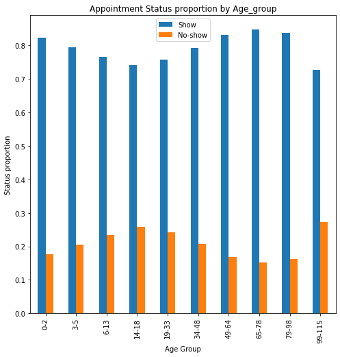

```python
df_age_norm.plot(kind='bar', figsize=(8,8));
plt.title('Appointment Status proportion by Age_group');
plt.xlabel('Age Group');
plt.ylabel('Status proportion');
```

#### Appointment status proportion by age group

> 84.7% of Those within the age group of 65-78 show up for their appointments. This is the highest rate compared to other age groups. The group with the highest rate of no-show were those within the age group of 99-115 with 27% no show. It is possible that being elderly, they needed help from others to take them to see the doctor. However, since they had the smallest sample size in the distribution, we may need to investigate this further.

### Research Question 3 (Considering both age and gender, how does these relate with the appointment status?)

## Status by Age_group and Gender

```python
age_gender_status = df_cleaned.groupby(['Age_group','Gender'])['status'].value_counts()
```

```python
# unpack the age_gender_status into to list 'show' and 'no_show'
show=[]
no_show=[]
unpacker(age_gender_status,show,no_show)
print("show: {}".format(show))
print("no_show: {}".format(no_show))
```

```
show: [2934, 3190, 1611, 1811, 3822, 4161, 3277, 1713, 11847, 4244, 11918, 5307, 13642, 6561, 6073, 2954, 2115, 1019, 6, 2]
no_show: [632, 674, 427, 452, 1158, 1266, 1093, 644, 3792, 1348, 3150, 1363, 2823, 1260, 1106, 516, 407, 200, 3]
```

```python
# unpacking the shows into female_show and male_show
female_show=[]
male_show=[]
unpacker(show,female_show,male_show)
print("female_show: {}".format(female_show))
print("male_show: {}".format(male_show))
```

```
female_show: [2934, 1611, 3822, 3277, 11847, 11918, 13642, 6073, 2115, 6]
male_show: [3190, 1811, 4161, 1713, 4244, 5307, 6561, 2954, 1019, 2]
```

```python
#unpacking the noshows into female_no_show and male_no-show
female_no_show=[]
male_no_show=[]
unpacker(no_show,female_no_show,male_no_show)
print("female_no_show: {}".format(female_no_show))
print("male_no_show: {}".format(male_no_show))
```

```
female_no_show: [632, 427, 1158, 1093, 3792, 3150, 2823, 1106, 407, 3]
male_no_show: [674, 452, 1266, 644, 1348, 1363, 1260, 516, 200]
```

```python
# male no_show is 9; filling in the 10th position with 0
male_no_show.insert(9,0)
```

```python
#creating a dataframe for male status by age and gender
df_age_gender_status = pd.DataFrame({'male_show':male_show,'male_no_show':male_no_show,'female_show':female_show,'female_no_show':female_no_show},index=labels)
df_age_gender_status
```

|  | male_show | male_no_show | female_show | female_no_show |
| --- | --- | --- | --- | --- |
| 0-2 | 3190 | 674 | 2934 | 632 |
| 3-5 | 1811 | 452 | 1611 | 427 |
| 6-13 | 4161 | 1266 | 3822 | 1158 |
| 14-18 | 1713 | 644 | 3277 | 1093 |
| 19-33 | 4244 | 1348 | 11847 | 3792 |
| 34-48 | 5307 | 1363 | 11918 | 3150 |
| 49-64 | 6561 | 1260 | 13642 | 2823 |
| 65-78 | 2954 | 516 | 6073 | 1106 |
| 79-98 | 1019 | 200 | 2115 | 407 |
| 99-115 | 2 | 0 | 6 | 3 |

Here is a dataframe showing the show and no_show rate per age_group, per gender. This makes it easy to compare the show and no_show rate across the group. However, let's present this information on a plot for better visualization

```python
# defining a function, double_stacked barchart
def double_stacked_barchart(df_01):
    '''
    Plots a double stacked barchart using the the four columns in the dataframe

    args:
    args_1(DataFrame): The dataframe to plot from

    Returns:
    bar_1: The first bar from first column
    bar_2: The second bar from third column
    bar_3: The third bar from second column
    bar_4: The fourth bar from fourth column
    loc: The x_ticks locations

    '''
    #unpack the relevant series objects from th df
    index= df_01.index
    series_1=df_01.iloc[:,0]
    series_2=df_01.iloc[:,2]
    series_3=df_01.iloc[:,1]
    series_4=df_01.iloc[:,3]
    #The x location

    ind=np.arange(len(index))
    width=0.35
    # creating a plot to show the status by age and gender
    fig,ax=plt.subplots()
    bar_1= ax.bar(ind, series_1,width,color='#1f77b4')
    bar_2=ax.bar(ind, series_2,width, bottom=series_1,color='#ff7f0e')
    bar_3=ax.bar(ind+width, series_3,width,color='#144c73')
    bar_4=ax.bar(ind+width, series_4,width, bottom=series_3,color='#8e4200')
    loc=ind+width/2


    return (bar_1,bar_2,bar_3,bar_4,loc)
```

The definition of the double stacked bar chart

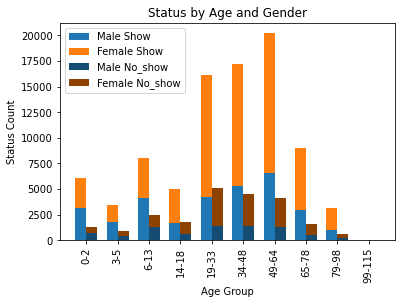

```python
# ploting a double stacked barchart
a,b,c,d,e=double_stacked_barchart(df_age_gender_status);
#title and labels
plt.ylabel('Status Count')
plt.xlabel('Age Group')
plt.title('Status by Age and Gender')

labels=["0-2","3-5","6-13","14-18","19-33","34-48","49-64","65-78","79-98","99-115"]
plt.xticks(e,labels,rotation=90)
a.set_label('Male Show')
b.set_label('Female Show')
c.set_label('Male No_show')
d.set_label('Female No_show')

#legend
plt.legend();
```

### Status count by age and Gender

> To know if females keep their appointment more than males across the age group lets check the proportion of males to females that kept their appointment across the group

# Proportion by Age and Gender

```python
#group by Age_group and Gender then normalize
norm_age_gender_status = df_cleaned.groupby(['Age_group','Gender'])['status'].value_counts(normalize=True)
```

norm_age_gender_status is the normalized count of the status by age and gender

```python
# unpack the age_gender_status into to list 'show' and 'no_show'
show=[]
no_show=[]
unpacker(norm_age_gender_status,show,no_show)
print("show: {}".format(show))
print("no_show: {}".format(no_show))
```

```
show: [0.8227706113292205, 0.8255693581780539, 0.7904808635917566, 0.8002651347768449, 0.7674698795180723, 0.7667219458264234, 0.7498855835240275, 0.7267713194739075, 0.7575292537886054, 0.7589413447782547, 0.7909477037430316, 0.7956521739130434, 0.8285453993319162, 0.8388952819332566, 0.84593954589…
no_show: [0.1772293886707796, 0.17443064182194618, 0.20951913640824338, 0.19973486522315512, 0.2325301204819277, 0.23327805417357655, 0.25011441647597255, 0.2732286805260925, 0.24247074621139458, 0.24105865522174535, 0.20905229625696842, 0.20434782608695654, 0.17145460066808382, 0.1611047180667434, …
```

The norm_age_gender_status list is now unpacked into show and no_show using the unpacker function

```python
# unpacking the shows into female_show and male_show
female_show=[]
male_show=[]
unpacker(show,female_show,male_show)
print("female_show: {}".format(female_show))
print("male_show: {}".format(male_show))
```

```
female_show: [0.8227706113292205, 0.7904808635917566, 0.7674698795180723, 0.7498855835240275, 0.7575292537886054, 0.7909477037430316, 0.8285453993319162, 0.8459395458977573, 0.8386201427438541, 0.6666666666666666]
male_show: [0.8255693581780539, 0.8002651347768449, 0.7667219458264234, 0.7267713194739075, 0.7589413447782547, 0.7956521739130434, 0.8388952819332566, 0.8512968299711815, 0.8359310910582445, 1.0]
```

The list,show is further unpacked into two categories for male show and female show.

```python
#unpacking the noshows into female_no_show and male_no-show
female_no_show=[]
male_no_show=[]
unpacker(no_show,female_no_show,male_no_show)
print("female_no_show: {}".format(female_no_show))
print("male_no_show: {}".format(male_no_show))
```

```
female_no_show: [0.1772293886707796, 0.20951913640824338, 0.2325301204819277, 0.25011441647597255, 0.24247074621139458, 0.20905229625696842, 0.17145460066808382, 0.15406045410224264, 0.16137985725614593, 0.3333333333333333]
male_no_show: [0.17443064182194618, 0.19973486522315512, 0.23327805417357655, 0.2732286805260925, 0.24105865522174535, 0.20434782608695654, 0.1611047180667434, 0.14870317002881844, 0.16406890894175555]
```

likewise, the list, no_show is further unpacked into two categories for male and female no_show

```python
# male no_show is 9; filling in the 10th position with 0
male_no_show.insert(9,0)
male_no_show
```

```
[0.17443064182194618,
 0.19973486522315512,
 0.23327805417357655,
 0.2732286805260925,
 0.24105865522174535,
 0.20434782608695654,
 0.1611047180667434,
 0.14870317002881844,
 0.16406890894175555,
 0]
```

for age group `99-115` it was observed that there was no record for a no_show.Therefore, the space was filled with 0

```python
#creating a dataframe for male status by age and gender
df_prop_age_gender = pd.DataFrame({'Prop_male_show':male_show,'Prop_male_no_show':male_no_show,'Prop_female_show':female_show,'Prop_female_no_show':female_no_show},index=labels)
df_prop_age_gender
```

|  | Prop_male_show | Prop_male_no_show | Prop_female_show | Prop_female_no_show |
| --- | --- | --- | --- | --- |
| 0-2 | 0.825569 | 0.174431 | 0.822771 | 0.177229 |
| 3-5 | 0.800265 | 0.199735 | 0.790481 | 0.209519 |
| 6-13 | 0.766722 | 0.233278 | 0.767470 | 0.232530 |
| 14-18 | 0.726771 | 0.273229 | 0.749886 | 0.250114 |
| 19-33 | 0.758941 | 0.241059 | 0.757529 | 0.242471 |
| 34-48 | 0.795652 | 0.204348 | 0.790948 | 0.209052 |
| 49-64 | 0.838895 | 0.161105 | 0.828545 | 0.171455 |
| 65-78 | 0.851297 | 0.148703 | 0.845940 | 0.154060 |
| 79-98 | 0.835931 | 0.164069 | 0.838620 | 0.161380 |
| 99-115 | 1.000000 | 0.000000 | 0.666667 | 0.333333 |

Here is a dataframe showing the show and no_show rate per age_group for each gender. This makes it easy to compare the show and no show rate across the group. However, let's present this information on a plot for better visualization

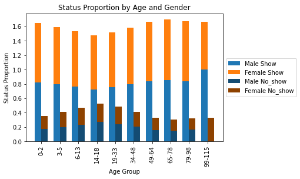

```python
# ploting a double stacked barchart
a,b,c,d,e=double_stacked_barchart(df_prop_age_gender);
#title and labels
plt.ylabel('Status Count')
plt.xlabel('Age Group')
plt.title('Status by Age and Gender')


#title and labels
plt.ylabel('Status Proportion')
plt.xlabel('Age Group')
plt.title('Status Proportion by Age and Gender')
plt.xticks(e,labels,rotation=90)
a.set_label('Male Show')
b.set_label('Female Show')
c.set_label('Male No_show')
d.set_label('Female No_show')

#legend
plt.legend(loc='center left',bbox_to_anchor=(1,0.5));
```

### Status proportion by Age and Gender

##### The proportion is fairly even but the male population seem to show up more than the female by a slight margin.

> for instance, we can see that for the group with the highest show rate, i.e the age group `65-78`, the male population has a show up rate of `85%` while the female population has a show up rate of `84.5%`.

> It can also be observed that the male population within the Age Group **99-155** all showed up and that 100% of the no show in that group is accounted for by the female gender. However, this might be due to the disproportionately large number of females in that group.

eda

# Time Factor

### Research Question 4 (Is waiting time an indicator for whether an individual show up or not?)

> Now we will look at the influence of time on whether a patient shows up or not.

### considering the waiting time

```python
df_cleaned.head()
```

|  | Gender | Age | Neighbourhood | sponsorship | Hipertension | Diabetes | Alcoholism | Handcap | SMS_received | Waiting_time | appointment_weekday | status | Age_group |
| --- | --- | --- | --- | --- | --- | --- | --- | --- | --- | --- | --- | --- | --- |
| 0 | F | 62 | JARDIM DA PENHA | 0 | 1 | 0 | 0 | 0 | 0 | 0 | 4 | show | (48, 64] |
| 1 | M | 56 | JARDIM DA PENHA | 0 | 0 | 0 | 0 | 0 | 0 | 0 | 4 | show | (48, 64] |
| 2 | F | 62 | MATA DA PRAIA | 0 | 0 | 0 | 0 | 0 | 0 | 0 | 4 | show | (48, 64] |
| 3 | F | 8 | PONTAL DE CAMBURI | 0 | 0 | 0 | 0 | 0 | 0 | 0 | 4 | show | (5, 13] |
| 4 | F | 56 | JARDIM DA PENHA | 0 | 1 | 1 | 0 | 0 | 0 | 0 | 4 | show | (48, 64] |

```python
# a value count of the status grouped by waiting time
waiting_status = df_cleaned.groupby('Waiting_time')['status'].value_counts()
waiting_status
```

```
Waiting_time  status
0             show       36770
              no-show     1792
1             show        4100
              no-show     1113
2             show        5123
                         ...
169           no-show        1
176           show          10
              no-show        6
179           show           8
              no-show        2
Name: status, Length: 235, dtype: int64
```

### examining the waiting time

> It can be observed that the waiting time ranges between 0 to 179 days.

> Also, for most of the population the waiting time is between 0 and 30 days and the distribution is greatly skewed to the right.

```python
# examining the range of the waiting time
df_cleaned['Waiting_time'].describe()
```

```
count    110521.000000
mean         10.184345
std          15.255153
min           0.000000
25%           0.000000
50%           4.000000
75%          15.000000
max         179.000000
Name: Waiting_time, dtype: float64
```

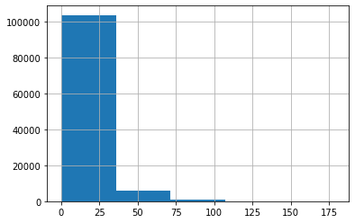

```python
# a plot of the distribution of the waiting time
df_cleaned['Waiting_time'].hist(bins=5);
```

This distribution plot of the waiting time show that over 80% of the waiting time was within 0 and 30 days

> First, to simplify the analysis we are going to bin the waiting time into groups of 20

```python
# creating the arguments
lab=['Twenty_days','Forty_days','Sixty_days','Eighty_days','Hundred_days','One_twenty_days','One_forty_days','one_sixty_days','one_eigthy_days']
waiting_time=df_cleaned['Waiting_time']
```

```python
#binning the waiting_time
df_cleaned["waiting_group"]=pd.cut(waiting_time,9,labels=lab)

#Checking for nulls
df_cleaned['waiting_group'].isnull().sum()
```

```
0
```

Having binned the waiting time into set of 20s we check to ensure that all waiting time value has been captured. The return value of 0 is a confirmation.

```python
df_cleaned.head()
```

|  | Gender | Age | Neighbourhood | sponsorship | Hipertension | Diabetes | Alcoholism | Handcap | SMS_received | Waiting_time | appointment_weekday | status | Age_group | waiting_group |
| --- | --- | --- | --- | --- | --- | --- | --- | --- | --- | --- | --- | --- | --- | --- |
| 0 | F | 62 | JARDIM DA PENHA | 0 | 1 | 0 | 0 | 0 | 0 | 0 | 4 | show | (48, 64] | Twenty_days |
| 1 | M | 56 | JARDIM DA PENHA | 0 | 0 | 0 | 0 | 0 | 0 | 0 | 4 | show | (48, 64] | Twenty_days |
| 2 | F | 62 | MATA DA PRAIA | 0 | 0 | 0 | 0 | 0 | 0 | 0 | 4 | show | (48, 64] | Twenty_days |
| 3 | F | 8 | PONTAL DE CAMBURI | 0 | 0 | 0 | 0 | 0 | 0 | 0 | 4 | show | (5, 13] | Twenty_days |
| 4 | F | 56 | JARDIM DA PENHA | 0 | 1 | 1 | 0 | 0 | 0 | 0 | 4 | show | (48, 64] | Twenty_days |

```python
#grouping status by waiting_group
waiting_group_status = df_cleaned.groupby('waiting_group')['status'].value_counts()
waiting_group_status
```

```
waiting_group    status
Twenty_days      show       73492
                 no-show    15106
Forty_days       show       11016
                 no-show     5473
Sixty_days       show        2158
                 no-show     1108
Eighty_days      show        1204
                 no-show      506
Hundred_days     show         240
                 no-show       80
One_twenty_days  show          41
                 no-show       12
One_forty_days   show          13
                 no-show        7
one_sixty_days   no-show       11
                 show           9
one_eigthy_days  show          34
                 no-show       11
Name: status, dtype: int64
```

### Waiting_group_status distribution

> just as in the distribution plot above we can see that most of the appointments were scheduled with 20 days waiting period. There is therefore, a higher occurence of the **twenty_days** group

> Due to this large count of the 20days waiting group, a countplot will be biased towards that group. Therefore we will plot the proportion of the appointment status across the waiting group.

```python
#grouping status by waiting_group
waiting_group_status = df_cleaned.groupby('waiting_group')['status'].value_counts(normalize=True)
waiting_group_status
```

```
waiting_group    status
Twenty_days      show       0.829500
                 no-show    0.170500
Forty_days       show       0.668082
                 no-show    0.331918
Sixty_days       show       0.660747
                 no-show    0.339253
Eighty_days      show       0.704094
                 no-show    0.295906
Hundred_days     show       0.750000
                 no-show    0.250000
One_twenty_days  show       0.773585
                 no-show    0.226415
One_forty_days   show       0.650000
                 no-show    0.350000
one_sixty_days   no-show    0.550000
                 show       0.450000
one_eigthy_days  show       0.755556
                 no-show    0.244444
Name: status, dtype: float64
```

It can be observed that the show rate is highest for waiting period within 20 days at 82.9%

```python
# unpacking  the list waiting_group_status
show=[]
no_show=[]
unpacker(waiting_group_status,show,no_show)
print("show: {}".format(show))
print("no_show: {}".format(no_show))
```

```
show: [0.8294995372356035, 0.6680817514706774, 0.6607470912431108, 0.704093567251462, 0.75, 0.7735849056603774, 0.65, 0.55, 0.7555555555555555]
no_show: [0.17050046276439648, 0.33191824852932256, 0.3392529087568892, 0.295906432748538, 0.25, 0.22641509433962265, 0.35, 0.45, 0.24444444444444444]
```

waiting_group_status has been unpacked into two list, show and no_show

```python
# creating a dataframe
df_waiting_group=pd.DataFrame({'Show':show,'No_show':no_show},index=lab)
df_waiting_group
```

[output not shown]

Here is a dataframe showing the show and no_show rate per waiting group this makes it easy to compare the show and no show rate across the group. However, let's present this information on a plot for better visualization

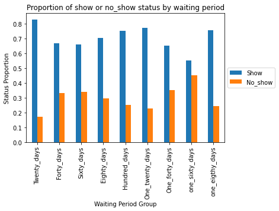

```python
df_waiting_group.plot(kind='bar');
plt.xlabel('Waiting Period Group')
plt.ylabel('Status Proportion')
plt.legend(loc='center left',bbox_to_anchor=(1,0.5))
plt.title('Proportion of show or no_show status by waiting period');
```

### Proportion of show and no_show status by waiting period

> This plot shows that the highest rate of show up status is in the waiting group less than 20 days Also, the lowest rate of no_show is within the same group

```python
# the status for waiting time less than 20 days
twenty_days_status=df_cleaned[df_cleaned['waiting_group']=='Twenty_days'][['Waiting_time','status']]
twenty_days_status.head()
```

|  | Waiting_time | status |
| --- | --- | --- |
| 0 | 0 | show |
| 1 | 0 | show |
| 2 | 0 | show |
| 3 | 0 | show |
| 4 | 0 | show |

filtered the cleaned data frame for status with waiting time less than 20

```python
# value count of show and no show
twenty_days_count=twenty_days_status.groupby('Waiting_time')['status'].value_counts()
twenty_days_count
```

```
Waiting_time  status
0             show       36770
              no-show     1792
1             show        4100
              no-show     1113
2             show        5123
              no-show     1602
3             show        2093
              no-show      644
4             show        4059
              no-show     1231
5             show        2405
              no-show      872
6             show        3036
              no-show     1001
7             show        3597
              no-show     1309
8             show        1662
              no-show      670
9             show        1165
              no-show      440
10            show         951
              no-show      440
11            show         675
              no-show      312
12            show         762
              no-show      353
13            show        1146
              no-show      536
14            show        2000
              no-show      913
15            show        1001
              no-show      502
16            show         800
              no-show      351
17            show         757
              no-show      350
18            show         709
              no-show      312
19            show         681
              no-show      363
Name: status, dtype: int64
```

#### Due to the large count of the 0 day waiting period we will analyse by proportion

```python
# value count of show and no show
twenty_days_prop=twenty_days_status.groupby('Waiting_time')['status'].value_counts(normalize=True)
twenty_days_prop
```

```
Waiting_time  status
0             show       0.953529
              no-show    0.046471
1             show       0.786495
              no-show    0.213505
2             show       0.761784
              no-show    0.238216
3             show       0.764706
              no-show    0.235294
4             show       0.767297
              no-show    0.232703
5             show       0.733903
              no-show    0.266097
6             show       0.752044
              no-show    0.247956
7             show       0.733184
              no-show    0.266816
8             show       0.712693
              no-show    0.287307
9             show       0.725857
              no-show    0.274143
10            show       0.683681
              no-show    0.316319
11            show       0.683891
              no-show    0.316109
12            show       0.683408
              no-show    0.316592
13            show       0.681332
              no-show    0.318668
14            show       0.686577
              no-show    0.313423
15            show       0.666001
              no-show    0.333999
16            show       0.695048
              no-show    0.304952
17            show       0.683830
              no-show    0.316170
18            show       0.694417
              no-show    0.305583
19            show       0.652299
              no-show    0.347701
Name: status, dtype: float64
```

Analysis by proportion reveals that the waiting period with the highest show rate is day 0 with 95% show rate

```python
# unpacking the twenty_days_count
show=[]
no_show=[]
unpacker(twenty_days_prop,show,no_show)
print("show: {}".format(show))
print("no_show: {}".format(no_show))
```

```
show: [0.9535293812561589, 0.7864953002110109, 0.7617843866171004, 0.7647058823529411, 0.767296786389414, 0.7339029600244126, 0.7520435967302452, 0.7331838565022422, 0.7126929674099486, 0.7258566978193146, 0.6836808051761323, 0.6838905775075987, 0.683408071748879, 0.6813317479191439, 0.6865774116031…
no_show: [0.046470618743841084, 0.21350469978898906, 0.23821561338289962, 0.23529411764705882, 0.23270321361058602, 0.2660970399755874, 0.24795640326975477, 0.26681614349775784, 0.28730703259005147, 0.27414330218068533, 0.3163191948238677, 0.3161094224924012, 0.3165919282511211, 0.31866825208085614,…
```

Here we have unpacked the twenty_day_prop list into two lists, show and no-show

```python
# creating the index
ind=np.arange(20)
ind
```

```
array([ 0,  1,  2,  3,  4,  5,  6,  7,  8,  9, 10, 11, 12, 13, 14, 15, 16,
       17, 18, 19])
```

using the numpy function arange we have created an array that will represent our index

```python
# creating the dataframe
df_20=pd.DataFrame({'Show':show,'No_show':no_show},index=ind)
df_20
```

|  | Show | No_show |
| --- | --- | --- |
| 0 | 0.953529 | 0.046471 |
| 1 | 0.786495 | 0.213505 |
| 2 | 0.761784 | 0.238216 |
| 3 | 0.764706 | 0.235294 |
| 4 | 0.767297 | 0.232703 |
| 5 | 0.733903 | 0.266097 |
| 6 | 0.752044 | 0.247956 |
| 7 | 0.733184 | 0.266816 |
| 8 | 0.712693 | 0.287307 |
| 9 | 0.725857 | 0.274143 |
| 10 | 0.683681 | 0.316319 |
| 11 | 0.683891 | 0.316109 |
| 12 | 0.683408 | 0.316592 |
| 13 | 0.681332 | 0.318668 |
| 14 | 0.686577 | 0.313423 |
| 15 | 0.666001 | 0.333999 |
| 16 | 0.695048 | 0.304952 |
| 17 | 0.683830 | 0.316170 |
| 18 | 0.694417 | 0.305583 |
| 19 | 0.652299 | 0.347701 |

Here is a dataframe showing the show and no_show rate per waiting period this makes it easy to compare the show and no show rate across the group. However, let's present this information on a plot for better visualization

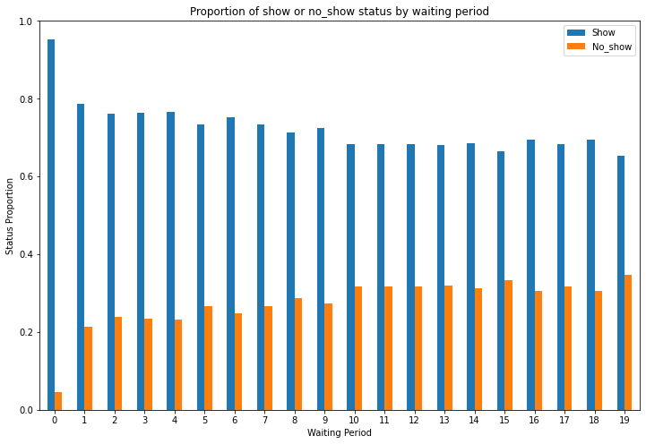

```python
df_20.plot(kind='bar',figsize=(12,8));
plt.xlabel('Waiting Period')
plt.ylabel('Status Proportion')
plt.tick_params(axis='x',rotation=0)
plt.title('Proportion of show or no_show status by waiting period');
```

### Proportion of show and no_show by waiting period.

This plot shows very clearly that the waiting period has an influence on the show and no_show status.

The more the waiting period, the lesser the rate of showing up.

eda

## What Day of the week

### Research Question 5 (Is the appointment week-day an indicator for whether an individual show up or not)

> Now we will look at the influence of the weekday on whether a patient shows up or not.

```python
week_day_status=df_cleaned[['appointment_weekday','status']]
week_day_status.head()
```

|  | appointment_weekday | status |
| --- | --- | --- |
| 0 | 4 | show |
| 1 | 4 | show |
| 2 | 4 | show |
| 3 | 4 | show |
| 4 | 4 | show |

`df_cleaned` was filtered to show only `appointment_weekday` and `status` the returned value is then assigned to `week_day_status`

```python
#grouping status by appointment_weekday
week_day_count=week_day_status['appointment_weekday'].value_counts(sort=False)
week_day_count
```

```
4    19019
1    25638
0    22713
2    25866
3    17246
5       39
Name: appointment_weekday, dtype: int64
```

```python
count=[]
# unpacking week_day_count
for day in week_day_count:
     count.append(day)
```

unpacking the count into a list `count`

```python
weekday=['Mon','Tue','Wed','Thur','Fri','Sat']
#dataframe
df_weekday_count=pd.DataFrame({'Status_count':count},index=weekday)
df_weekday_count
```

[output not shown]

Here is a dataframe showing the count of appointment per weekday this makes it easy to compare count across the group. However, let's present this information on a plot for better visualization

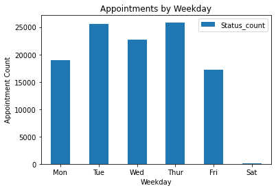

```python
df_weekday_count.plot(kind='bar')
plt.xlabel('Weekday')
plt.ylabel('Appointment Count')
plt.tick_params(axis='x',rotation=0)
plt.title('Appointments by Weekday');
```

## Lets consider the proportion of Show to no show per weekday

```python
week_day_prop = week_day_status.groupby('appointment_weekday')['status'].value_counts(normalize=True)
week_day_prop
```

```
appointment_weekday  status
0                    show       0.793554
                     no-show    0.206446
1                    show       0.799126
                     no-show    0.200874
2                    show       0.803139
                     no-show    0.196861
3                    show       0.806506
                     no-show    0.193494
4                    show       0.787739
                     no-show    0.212261
5                    show       0.769231
                     no-show    0.230769
Name: status, dtype: float64
```

`week_day_prop` is a normalized count of the `status` by `appointment_weekday` containing the rate of show and no show ratio per weekday

```python
# unpacking the week_days_count
show=[]
no_show=[]
unpacker(week_day_prop,show,no_show)
print("show: {}".format(show))
print("no_show: {}".format(no_show))
```

```
show: [0.7935543521331396, 0.7991262969030346, 0.803139256166396, 0.8065058564304767, 0.7877385772122614, 0.7692307692307693]
no_show: [0.2064456478668604, 0.20087370309696545, 0.19686074383360397, 0.19349414356952338, 0.21226142278773857, 0.23076923076923078]
```

`week_day_prop` unpacked into two list,show and no_show ordered by the weekday

```python
#creating the data frame
df_week_day=pd.DataFrame({'Show':show,'No_show':no_show}, index=weekday)
df_week_day
```

|  | Show | No_show |
| --- | --- | --- |
| Mon | 0.793554 | 0.206446 |
| Tue | 0.799126 | 0.200874 |
| Wed | 0.803139 | 0.196861 |
| Thur | 0.806506 | 0.193494 |
| Fri | 0.787739 | 0.212261 |
| Sat | 0.769231 | 0.230769 |

Here is a dataframe showing the show and no_show rate per weekday this makes it easy to compare the show and no show rate across the group. However, let's present this information on a plot for better visualization

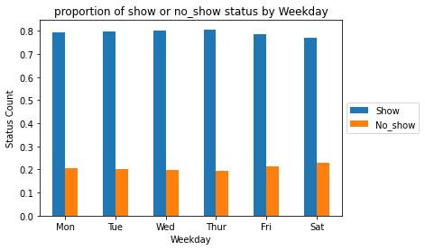

```python
# plotting the count
df_week_day.plot(kind='bar');
plt.xlabel('Weekday')
plt.ylabel('Status Count')
plt.legend(loc='center left',bbox_to_anchor=(1,0.5))
plt.tick_params(axis='x',rotation=0)
plt.title('proportion of show or no_show status by Weekday');
```

## Show or No_show proportion by Weekday

This plot show that the proportion of show and no show across each week day is relatively the same. However, the proportion of no_show is slightly higher on Saturday at 23%. As we saw in the previous plot there was very little appointment scheduled on saturday. we will need to examine more data to understand why.

`return`

What day of the Weekday

eda

# Ailment type

### Research Question 6 (Is there any relationship between the type of ailment and the appointment status.)

> Now we will look at the influence of the ailment type on whether a patient shows up or not.

```python
df_cleaned.head()
```

|  | Gender | Age | Neighbourhood | sponsorship | Hipertension | Diabetes | Alcoholism | Handcap | SMS_received | Waiting_time | appointment_weekday | status | Age_group | waiting_group |
| --- | --- | --- | --- | --- | --- | --- | --- | --- | --- | --- | --- | --- | --- | --- |
| 0 | F | 62 | JARDIM DA PENHA | 0 | 1 | 0 | 0 | 0 | 0 | 0 | 4 | show | (48, 64] | Twenty_days |
| 1 | M | 56 | JARDIM DA PENHA | 0 | 0 | 0 | 0 | 0 | 0 | 0 | 4 | show | (48, 64] | Twenty_days |
| 2 | F | 62 | MATA DA PRAIA | 0 | 0 | 0 | 0 | 0 | 0 | 0 | 4 | show | (48, 64] | Twenty_days |
| 3 | F | 8 | PONTAL DE CAMBURI | 0 | 0 | 0 | 0 | 0 | 0 | 0 | 4 | show | (5, 13] | Twenty_days |
| 4 | F | 56 | JARDIM DA PENHA | 0 | 1 | 1 | 0 | 0 | 0 | 0 | 4 | show | (48, 64] | Twenty_days |

```python
# getting the count of all ailment
ail_count=[]
column= ['Hipertension','Diabetes','Alcoholism']
for ailment in column:
     a=sum(df_cleaned[ailment]==1)
     print('{} : {}'.format(ailment,a))
     ail_count.append(a)
```

```
Hipertension : 21801
Diabetes : 7943
Alcoholism : 3360
```

A count of the he occurence of the three ailment specified in the dataset, revealed that there are 21801 cases of hypertension, 7943 case of Diabetes and 3360 cases of Alcoholism

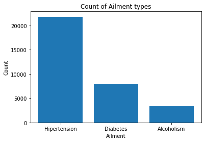

```python
# plot the bar charts
plt.bar(column,ail_count)
plt.xlabel('Ailment')
plt.ylabel('Count')
plt.title('Count of Ailment types');
```

#### Count of ailment types

This is a plot of the count of the three ailment types as they occur within the population.

```python
# filter through df_cleaned for those with different ailments
df_hyper= df_cleaned[df_cleaned['Hipertension']==1][['Hipertension','status']]
df_dia = df_cleaned[df_cleaned['Diabetes']==1][['Diabetes','status']]
df_alc = df_cleaned[df_cleaned['Alcoholism']==1][['Alcoholism','status']]
```

Filtering through df_cleaned for only occurence of the three ailments, `df_hyper` for hypertension, `df_dia` for diabetes and `df_alc` for alcoholism.

```python
# doing a normalized value count of the status for each slice
hyper=df_hyper['status'].value_counts(normalize=True)
hyper
```

```
show       0.82698
no-show    0.17302
Name: status, dtype: float64
```

Normalized value count for Hypertension per status.

```python
dia=df_dia['status'].value_counts(normalize=True)
dia
```

```
show       0.819967
no-show    0.180033
Name: status, dtype: float64
```

Normalized value count for Diabetes per status.

```python
alc=df_alc['status'].value_counts(normalize=True)
alc
```

```
show       0.798512
no-show    0.201488
Name: status, dtype: float64
```

Normalized value count for Alcoholism per status.

#### lets check the proportion of show and no show across the group

```python
show=[]
no_show=[]
```

```python
# unpacking the slices into two lists show and no_show
ailment=[hyper,dia,alc]
for ail in ailment:
 unpacker(ail,show,no_show)
```

Each of these normalized count are unpacked into two lists, `show` and `no_show`. ordered by `ailment`

```python
show
```

```
[0.8269804137424889, 0.8199672667757774, 0.7985119047619048]
```

patients with hypertension has the highest show rate at 82.6% followed by those with diabetes at 82%

```python
no_show
```

```
[0.17301958625751113, 0.18003273322422259, 0.20148809523809524]
```

The highest no show rate occurs amongpatients with Alcoholism at 20%

```python
# creating a dataframe
ail=['Hypertension','Diabetes','Alcoholism']
df_ail=pd.DataFrame({'Show':show,'no_show':no_show},index=ail)
df_ail
```

|  | Show | no_show |
| --- | --- | --- |
| Hypertension | 0.826980 | 0.173020 |
| Diabetes | 0.819967 | 0.180033 |
| Alcoholism | 0.798512 | 0.201488 |

Here is a dataframe showing the show and no_show rate per ailment this makes it easy to compare the show and no show rate across the group. However, let's present this information on a plot for better visualization.

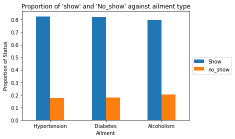

```python
# plot the bar charts
df_ail.plot(kind='bar')
plt.xlabel('Ailment')
plt.ylabel('Proportion of Status')
plt.tick_params(axis='x',rotation=0)
plt.legend(loc='center left',bbox_to_anchor=(1,0.5))
plt.title('Proportion of \'show\' and \'No_show\' against ailment type');
```

### Show and no_show proportion against ailment type

It can observed that the proportion of show and no_show is almost the same for the three groups. However, the rate of no_show is slightly higher among the alcoholism group with the highest no_show rate of 20%.

`return`

Ailment type

eda

## Research Question 7 (Is there any relationship between the Handicap type and the appointment status.)

```python
# getting the count of all type of handicap
hand_type=[]
for type in df_cleaned['Handcap'].unique():
    if type>0:
      a= sum(df_cleaned['Handcap']==type)
      print('{} : {}'.format(type,a))
      hand_type.append(a)
```

```
1 : 2040
2 : 183
3 : 13
4 : 3
```

A count of handicap by unique type shows that there are 2040 occurence of type `1`, 183 occurence of type `2`, 13 occurence of type `3` and 3 occurence of type`4`

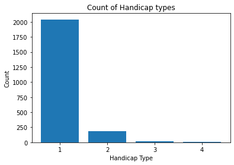

```python
# plot the bar charts
plt.bar(['1','2','3','4'],hand_type)
plt.xlabel('Handicap Type')
plt.ylabel('Count')
plt.title('Count of Handicap types');
```

## Handicap type count

This plot shows that the Handicap type `1` is the more prevalent type among the population with a count of 2040 occurences

> But what is the proportion of show and no show rate across the group?

```python
# grouping the Handcap column by status
Hand_status=df_cleaned.groupby('Handcap')['status'].value_counts(normalize=True)
Hand_status
```

```
Handcap  status
0        show       0.797667
         no-show    0.202333
1        show       0.821569
         no-show    0.178431
2        show       0.797814
         no-show    0.202186
3        show       0.769231
         no-show    0.230769
4        show       0.666667
         no-show    0.333333
Name: status, dtype: float64
```

Hand_status is contains the list of the show and no_show normalized count per handicap type

###### Note: that Handicap type 0 means no handicap/no disability

```python
# unparking Hand_status
show=[]
no_show=[]
unpacker(Hand_status,show,no_show)
```

```
([0.7976672023050922,
  0.8215686274509804,
  0.7978142076502732,
  0.7692307692307693,
  0.6666666666666666],
 [0.20233279769490775,
  0.1784313725490196,
  0.20218579234972678,
  0.23076923076923078,
  0.3333333333333333])
```

Hand_status is unpacked into two list `show` and `no_show`

```python
df_hand=pd.DataFrame({'Show':show,'no_show':no_show},index=['0','1','2','3','4'])
df_hand
```

|  | Show | no_show |
| --- | --- | --- |
| 0 | 0.797667 | 0.202333 |
| 1 | 0.821569 | 0.178431 |
| 2 | 0.797814 | 0.202186 |
| 3 | 0.769231 | 0.230769 |
| 4 | 0.666667 | 0.333333 |

Here is a dataframe showing the show and no_show rate per handicap type this makes it easy to compare the show and no show rate across the group. However, let's present this information on a plot for better visualization.

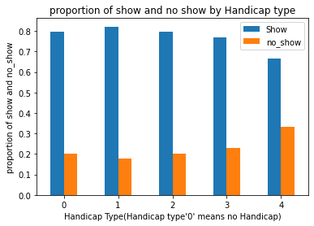

```python
df_hand.plot(kind='bar');
plt.xlabel('Handicap Type(Handicap type\'0\' means no Handicap)')
plt.ylabel('proportion of show and no_show')
plt.tick_params(axis='x',rotation=0)
plt.title('proportion of show and no show by Handicap type');
```

### Handicap type, Show and no_show proportion

Also, the population with type 4 handicap has the highest no show rate of 33%. The rate is much higher than the average no show rate across the entire group of 20.3%. This might be due to the nature of the disability.

`return`

Handicap status

eda

## Research Question 8 (Is there any relationship between the sponsorship status and the appointment status.)

```python
# value count of status grouped by sponsorship
sponsorship_status= df_cleaned.groupby('sponsorship')['status'].value_counts()
sponsorship_status.groupby('sponsorship').sum()
```

```
sponsorship
0    99660
1    10861
Name: status, dtype: int64
```

```python
status=['no_sponsorship','sponsorship']

# unpacking sponsorship_status into show and no_show
show=[]
no_show=[]
unpacker(sponsorship_status,show,no_show)
```

```
([79924, 8283], [19736, 2578])
```

sponsorship status was unpacked into two lists show and no_show

```python
# creating a dataframe
df_spon=pd.DataFrame({'show':show,'no_show':no_show},index=status)
df_spon
```

|  | show | no_show |
| --- | --- | --- |
| no_sponsorship | 79924 | 19736 |
| sponsorship | 8283 | 2578 |

Here is a dataframe showing the show and no_show count per sponsorship status this makes it easy to compare the show and no show count across the group. However, let's present this information on a plot for better visualization.

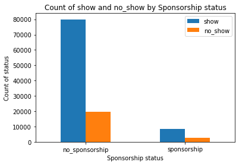

```python
# plotting count of show and no_show against sponsorship status
df_spon.plot(kind='bar')

# title and label
plt.xlabel('Sponsorship status')
plt.ylabel('Count of status')
plt.tick_params(axis='x',rotation=0)
plt.title('Count of show and no_show by Sponsorship status');
```

### Show and no_show count by Sponsorship status

It can be observed that 99660 observations were not enrolled in the Bolsa Familia program as compared to 10861 enrolled . This means that just about 10% were enrolled in the program

It might be difficult to compare the rate of show and no show between the two groups from the plot above. Therefore, lets compare by plotting the proportion of show and no_show across the group.

> lets find the rate of no_show between the two groups

```python
#Grouping the status by Scholarship and normalizing
sponsorship_prop= df_cleaned.groupby('sponsorship')['status'].value_counts(normalize=True)
sponsorship_prop
```

```
sponsorship  status
0            show       0.801967
             no-show    0.198033
1            show       0.762637
             no-show    0.237363
Name: status, dtype: float64
```

Sponsorship_prop shows the arte of show and no_show for each groups, those sponsored and those not sponsored.

```python
# unparking sponsorship_prop into show and no-show
status=['no_sponsorship','sponsorship']
show=[]
no_show=[]
unpacker(sponsorship_prop,show,no_show)
```

```
([0.8019666867348987, 0.7626369579228433],
 [0.19803331326510135, 0.2373630420771568])
```

sponsorship_prop is unpacked into two list, show and no_show.

```python
df_spon_prop=pd.DataFrame({'show':show,'no_show':no_show},index=status)
df_spon_prop
```

|  | show | no_show |
| --- | --- | --- |
| no_sponsorship | 0.801967 | 0.198033 |
| sponsorship | 0.762637 | 0.237363 |

Here is a dataframe showing the show and no_show rate per sponsorship status. this makes it easy to compare the show and no show rate across the group. However, let's present this information on a plot for better visualization.

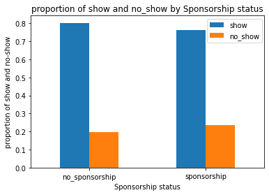

```python
df_spon_prop.plot(kind='bar')
plt.xlabel('Sponsorship status')
plt.ylabel('proportion of show and no-show')
plt.tick_params(axis='x',rotation=0)
plt.legend(loc='upper left',bbox_to_anchor=(0.74,1))
plt.title('proportion of show and no_show by Sponsorship status');
```

### Proportion of Show and no_show by sponsorship

It can be observed that there is a higher rate of no_show amongst those with sponsorship as compared to those without sponsorship.19% no show rate among for those without sponsorship and 23% no_show rate for those with sponsorship.

`return`

Sponsorship status

eda

## Appointment status against Handicap and sponsorship status

### Research Question 9 (How does scholarship and Handicap status affect the appointment status ?)

```python
# Grouping status by both Handicap and Scholarship column
spon_hand_stat=df_cleaned.groupby(['Handcap','sponsorship'])['status'].value_counts(normalize=True)
spon_hand_stat
```

```
Handcap  sponsorship  status
0        0            show       0.801648
                      no-show    0.198352
         1            show       0.761303
                      no-show    0.238697
1        0            show       0.820745
                      no-show    0.179255
         1            show       0.831250
                      no-show    0.168750
2        0            show       0.781818
                      no-show    0.218182
         1            show       0.944444
                      no-show    0.055556
3        0            show       0.769231
                      no-show    0.230769
4        0            show       0.666667
                      no-show    0.333333
Name: status, dtype: float64
```

`spon_hand_stat` contains the status grouped by `sponsorship` and `Handcap`

##### The handicap rows 3 and 4 has no scholarship values we will replace those with `0` to keep the list uniform.

to do this, we will first unpack spon_hand_stat into a list then replace the missing values with `0`

```python
# unpacking spon_hand_stat into a list
spon_hand=[]
for key,val in enumerate(spon_hand_stat):
    spon_hand.append(val)
```

`spon_hand_stat` unpacked into a list, `spon_hand` inorder to perform a list insert and append.

```python
# Appending with 0
spon_hand.insert(14,0)
spon_hand.insert(15,0)
spon_hand.append(0)
spon_hand.append(0)
```

Now we have uniform numbers of show and no_show for each Handicap group.

```python
#unpacking spon into show and no_show
show=[]
no_show=[]
unpacker(spon_hand,show,no_show)
```

```
([0.8016475578643224,
  0.7613030047739399,
  0.8207446808510638,
  0.83125,
  0.7818181818181819,
  0.9444444444444444,
  0.7692307692307693,
  0,
  0.6666666666666666,
  0],
 [0.19835244213567763,
  0.23869699522606008,
  0.17925531914893617,
  0.16875,
  0.21818181818181817,
  0.05555555555555555,
  0.23076923076923078,
  0,
  0.3333333333333333,
  0])
```

Using the unpacker function, `spon_hand` is unpacked into two list `show`,and `no_show`

```python
#unpacking show into two list one for those not sponsored and those sponsored
no_spon_show=[]
spon_show=[]
unpacker(show,no_spon_show,spon_show)
```

```
([0.8016475578643224,
  0.8207446808510638,
  0.7818181818181819,
  0.7692307692307693,
  0.6666666666666666],
 [0.7613030047739399, 0.83125, 0.9444444444444444, 0, 0])
```

The list, `show` is further unpacked based on their sponsorship status into `no-spon_show` and `spon_show`

```python
#unpacking no_show into two list one for those not sponsored and those sponsored
no_spon_no_show=[]
spon_no_show=[]
unpacker(no_show,no_spon_no_show,spon_no_show)
```

```
([0.19835244213567763,
  0.17925531914893617,
  0.21818181818181817,
  0.23076923076923078,
  0.3333333333333333],
 [0.23869699522606008, 0.16875, 0.05555555555555555, 0, 0])
```

As well, the list `no_show` is unpacked into two lists `no_spon_no_show` and `spon_no_show`

```python
#creating a data frame out of the four lists
hand_index=['0','1','2','3','4']
df_spon_hand=pd.DataFrame({'Sponsored_show':spon_show,'Sponsored_no_show':spon_no_show,'Not_sponsored_show':no_spon_show,'Not_sponsored_no_show':no_spon_no_show},index=hand_index)
df_spon_hand
```

|  | Sponsored_show | Sponsored_no_show | Not_sponsored_show | Not_sponsored_no_show |
| --- | --- | --- | --- | --- |
| 0 | 0.761303 | 0.238697 | 0.801648 | 0.198352 |
| 1 | 0.831250 | 0.168750 | 0.820745 | 0.179255 |
| 2 | 0.944444 | 0.055556 | 0.781818 | 0.218182 |
| 3 | 0.000000 | 0.000000 | 0.769231 | 0.230769 |
| 4 | 0.000000 | 0.000000 | 0.666667 | 0.333333 |

Here is a dataframe showing the show and no_show rate per sponsorship status per handicap group. this makes it easy to compare the show and no show rate across the group. However, let's present this information on a plot for better visualization.

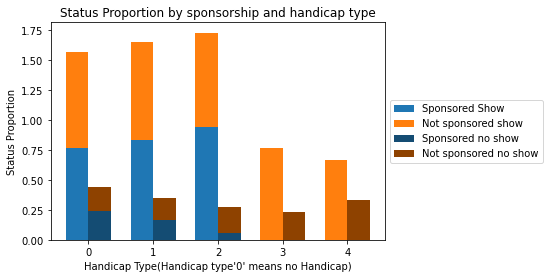

```python
# ploting a double stacked barchart
a,b,c,d,e=double_stacked_barchart(df_spon_hand);
#title and labels
plt.ylabel('Status Proportion')
plt.xlabel('Handicap Type(Handicap type\'0\' means no Handicap)')
plt.title('Status Proportion by sponsorship and handicap type')
plt.xticks(e,hand_index,rotation=0)
a.set_label('Sponsored Show')
b.set_label('Not sponsored show')
c.set_label('Sponsored no show')
d.set_label('Not sponsored no show')

#legend
plt.legend(loc='center left',bbox_to_anchor=(1,0.5));
```

### status proportion by sponsorship and Handicap Type

It can be observed that those with handicap were sponsored more than those without handicap.

Only those with handicap type 1 and 2 were sponsored while those with handicap type 3 and 4 were not sponsored

Those with handicap type 2 had the highest show rate with an average of 86% as compared to other handicap group.

Also, from the group with handicap type 2, there is a 94.4% show rate when sponsored and a 78% show rate when not sponsored.This is quite a significant difference.

The same pattern can be observed within the handicap type 1 group with 83% show rate when sponsored and 82 percent show rate when not sponsored

Conversly,the show rate reduces among those without any disability when sponsored. sponsored show rate is 76% and not sponsored show rate is 80.1%

It can be oserved that the no_show rate is highest in the group with handicap type 3 and 4. The handicap type 4 group has the highest overall no show rate of 33.3% followed by type 3 group with no_show rate of 23% `return`

Handicap and Sponsorship status

eda

## Sms reminder and its influence on show rate

### Research Question 10 (Is there any relationship between the sms reminder and the appointment status.)

```python
# count status grouped by SMS_received
sms_alert=df_cleaned.groupby('SMS_received')['status'].value_counts()
sms_alert
```

```
SMS_received  status
0             show       62509
              no-show    12530
1             show       25698
              no-show     9784
Name: status, dtype: int64
```

`sms_alert` contains the count of status grouped by whether or not they recieved an sms alert.

```python
#unpacking sms_alert into show and no_show
show=[]
no_show=[]
unpacker(sms_alert,show,no_show)
```

```
([62509, 25698], [12530, 9784])
```

`sms_alert` is unpacked into two list `show` and `no_show`.

```python
#creating a data_frame
index=['No_SMS_recieved','SMS_recieved']
df_alert=pd.DataFrame({'show':show,'no_show':no_show},index=index)
df_alert
```

|  | show | no_show |
| --- | --- | --- |
| No_SMS_recieved | 62509 | 12530 |
| SMS_recieved | 25698 | 9784 |

Here is a dataframe showing the show and no_show count per SMS_recieved_status. this makes it easy to compare the show and no show rate across the group. However, let's present this information on a plot for better visualization.

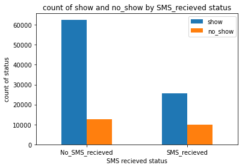

```python
#ploting the chart
df_alert.plot(kind='bar')
plt.xlabel('SMS recieved status')
plt.ylabel('count of status')
plt.tick_params(axis='x',rotation=0)
plt.legend(loc='upper left',bbox_to_anchor=(0.74,1))
plt.title('count of show and no_show by SMS_recieved status');
```

### Count of appointment status by SMS_recieved

It can be observed that `62,509` patients did not recieve any sms yet they showed up as compared to `25,698` that recieved alert and showed up. to have a better comparison between the two groups, let us consider the proportion of show and no_show per group.

```python
sms_alert_prop=df_cleaned.groupby('SMS_received')['status'].value_counts(normalize=True)
```

`sms_alert_prop` contains the rate of show and no-show status based on their SMS recieved status

```python
show_prop=[]
no_show_prop=[]
unpacker(sms_alert_prop,show_prop,no_show_prop)
```

```
([0.833020162848652, 0.7242545516036301],
 [0.16697983715134795, 0.27574544839637])
```

unpacking `sms_alert_prop` into two list `show`and `no_show`

```python
index=['No_SMS_recieved','SMS_recieved']
df_alert_prop=pd.DataFrame({'show':show_prop,'no_show':no_show_prop},index=index)
df_alert_prop
```

|  | show | no_show |
| --- | --- | --- |
| No_SMS_recieved | 0.833020 | 0.166980 |
| SMS_recieved | 0.724255 | 0.275745 |

Here is a dataframe showing the show and no_show rate per SMS_recieved_status. this makes it easy to compare the show and no show rate across the group. However, let's present this information on a plot for better visualization.

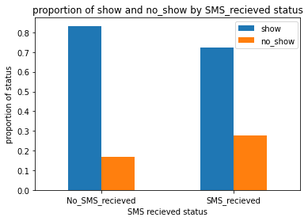

```python
# plotting proportion of status against SMS_recieved status
df_alert_prop.plot(kind='bar')

#title and label
plt.xlabel('SMS recieved status')
plt.ylabel('proportion of status')
plt.tick_params(axis='x',rotation=0)
plt.legend(loc='upper left',bbox_to_anchor=(0.74,1))
plt.title('proportion of show and no_show by SMS_recieved status');
```

### SMS _recieved status and proportion of show and no_show

The show rate is higher amongst he group without SMS Alert at 83% while the group that got sms alert have a show rate of 72.4%

we might need to compare against other features to get more insight.

`return`

SMS_recieved status

eda

## Conclusions

In this analysis our focus has been on discovering factors that best describe the show or no_show condition of the appointment status. In exploring the dataset, the following conclusion can be reached.

Gender is not a strong indicator as the difference in show rate between the two gender is less than 1%.The show rate for male is slightly higher at 80% while that of the female is at 79.7%

Age is a stronger indicator of no_show as the rate of no_show is low for children within the age group of 0-2 at 17.5% then increases continously until it peaks at the teenage group 14-18 at 25%. Then continues to reduce for adults before reaching its minimum for age group between 65-78 at 15% and then start to increase and peaks at age group 99-115 at 27%.

This describes the dire need for health care for babies under the age of 2 and the increased conciousness towards healthy living as one become adult. Also, the tendency for the aged ones between the ages 79 to 115 to need the help of others to help maintain their health.

When considering the waiting _periods within 20 days, we can see a steady increase in no_show rate as the waiting _period increases.

The ailment type is flat. Although, the rate of no show is highest among the alcoholism group at 20%, this is not much different from the diabetes and hypertension group at 18% and 17% respectively

The handicap type is a strong indicator of the show rate we can see that handicap type 1 has the lowest no show rate at 17.8%, this increases steadily across the handicap type 2 and 3 peaking at 33% for handicap type 4

It can also be observed that sponsorship(i.e enrollment status into the Bolsa Familia welfare program) has a strong effect on the no_show rate across the different handicap type group particularly for the type 2 Handicap group where there is 5.5% no show rate with sponsorship and 21.8% no_show rate without sponsorship.

### Limitations

A major limitation is the lack of sufficient data especially for older age groups like age group between 98-115. It is likely that their low representation in the data set is a true representation of the larger population,but this will need to be investigated further.

Another limitation is that the data set has focused mostly on ailments that are more prevalent among adult group between the ages 19 and 78.Therefore, limiting the scope of this analysis and also making it difficult to determine how this analysis may have been biased towards these age groups

```python
from subprocess import call
call(['python', '-m', 'nbconvert', 'Investigate_a_Dataset.ipynb'])
```

```
4294967295
```